# Analyse der Iris-Daten

import library

### R Markdown

```r
data("iris")  # Lädt den Iris-Datensatz
head(iris)    # Zeigt die ersten paar Zeilen des Datensatzes an
```

```
##   Sepal.Length Sepal.Width Petal.Length Petal.Width Species
## 1          5.1         3.5          1.4         0.2  setosa
## 2          4.9         3.0          1.4         0.2  setosa
## 3          4.7         3.2          1.3         0.2  setosa
## 4          4.6         3.1          1.5         0.2  setosa
## 5          5.0         3.6          1.4         0.2  setosa
## 6          5.4         3.9          1.7         0.4  setosa
```

### Erklärungen zu den Daten:

- Sepal.Length: Die Länge des Kelchblatts (Sepal) der Iris-Blume in Zentimetern.
- Sepal.Width: Die Breite des Kelchblatts der Iris-Blume in Zentimetern.
- Petal.Length: Die Länge des Blütenblatts (Petal) der Iris-Blume in Zentimetern.
- Petal.Width: Die Breite des Blütenblatts der Iris-Blume in Zentimetern.
- Species: Die Art der Iris-Blume. Im Datensatz gibt es drei Arten: Setosa, Versicolor und Virginica.

use the ggplot for all the tasks below - make a scatter plot with x-axis: Sepal.Length and y-axis: Sepal.Width, and the species should be shown in different colors - add regression line for the previous plot with the whole dataset (regardless of the species) - calculate the Pearson correlation for this plot

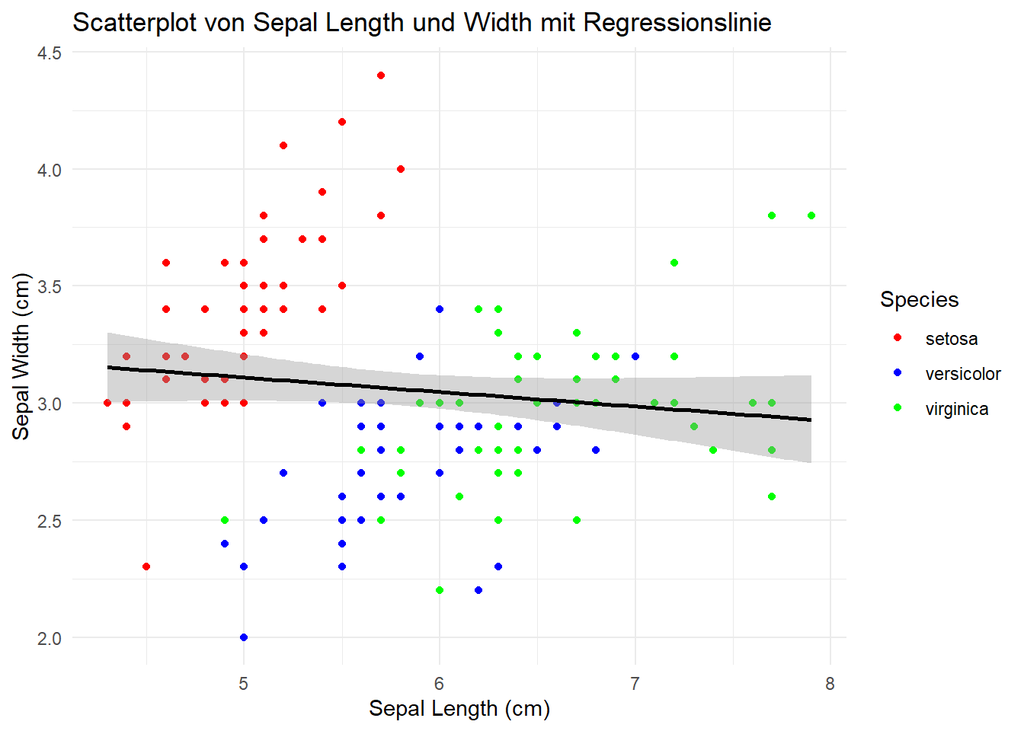

```r
# Erstellen des Scatterplots mit farblich unterschiedlichen Punkten je nach Spezies
ggplot(iris, aes(x = Sepal.Length, y = Sepal.Width, color = Species)) +
  geom_point() +  # Fügt die Punkte zum Graphen hinzu
  geom_smooth(method = "lm", color = "black") +  # Fügt eine Regressionslinie für den gesamten Datensatz hinzu
  scale_color_manual(values = c("setosa" = "red", "versicolor" = "blue", "virginica" = "green")) +
  labs(title = "Scatterplot von Sepal Length und Width mit Regressionslinie",
       x = "Sepal Length (cm)",
       y = "Sepal Width (cm)") + theme_minimal()
```

```r
# Berechnung der Pearson-Korrelation
correlation <- cor.test(iris$Sepal.Length, iris$Sepal.Width, method = "pearson")
correlation  # Gibt das Ergebnis der Korrelationsanalyse aus
```

```
##
##  Pearson's product-moment correlation
##
## data:  iris$Sepal.Length and iris$Sepal.Width
## t = -1.4403, df = 148, p-value = 0.1519
## alternative hypothesis: true correlation is not equal to 0
## 95 percent confidence interval:
##  -0.27269325  0.04351158
## sample estimates:
##        cor
## -0.1175698
```

Der Wert -0.117 als Korrelationskoeffizient zeigt eine sehr schwache negative Korrelation zwischen den beiden Variablen an, passend zur sehr leicht negativen Steigung der Regressionslinie im Scatterplot. Das 95%-Konfidenzintervall für den Korrelationskoeffizienten geht sogar über 0, was bedeutet, dass die Korrelation wahrscheinlich nicht signifikant ist.

Zwischen den einzelnen Spezies kann man aber im Scatterplot deutliche Zusammenhänge zwischen den beiden Variablen erkennen. Es ist zwar nicht in der Aufgabenstellung gefordert, aber ich wollte mir gern noch die Regressionslinien der einzelnen Species anzeigen lassen. Diese passen viel besser zu den Datenpunkten der Gruppen. Regression hat also nur Sinn, wenn die Daten entsprechend gruppiert sind.

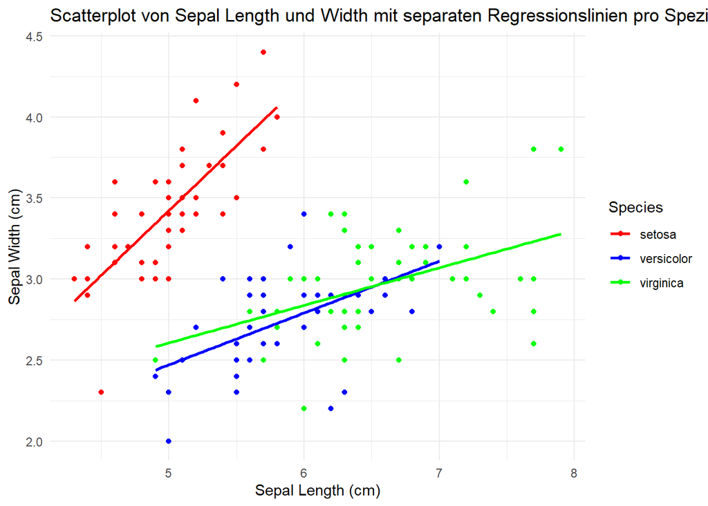

```r
# Erstellen des Scatterplots mit separaten Regressionslinien für jede Spezies
ggplot(iris, aes(x = Sepal.Length, y = Sepal.Width)) +
  geom_point(aes(color = Species)) +  # Fügt die Punkte mit Farben je nach Spezies hinzu
  geom_smooth(data = subset(iris, Species == "setosa"), method = "lm", aes(color = "setosa"), se = FALSE) +
  geom_smooth(data = subset(iris, Species == "versicolor"), method = "lm", aes(color = "versicolor"), se = FALSE) +
  geom_smooth(data = subset(iris, Species == "virginica"), method = "lm", aes(color = "virginica"), se = FALSE) +
  scale_color_manual(values = c("setosa" = "red", "versicolor" = "blue", "virginica" = "green")) +
  labs(title = "Scatterplot von Sepal Length und Width mit separaten Regressionslinien pro Spezies",
       x = "Sepal Length (cm)",
       y = "Sepal Width (cm)") + theme_minimal()
```

- make the boxplot for Petal.Width with 3 species separately in the x-axis in different colors

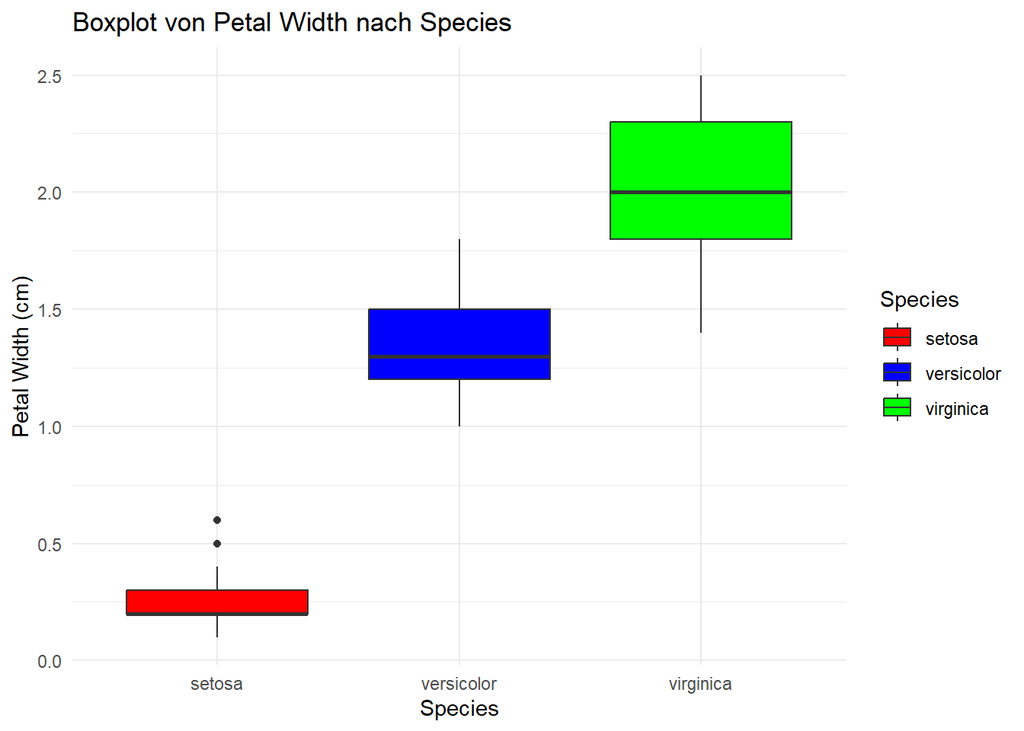

```r
# Boxplot für Petal.Width nach Species
ggplot(iris, aes(x = Species, y = Petal.Width, fill = Species)) +
  geom_boxplot() +
  scale_fill_manual(values = c("setosa" = "red", "versicolor" = "blue", "virginica" = "green")) +
  labs(title = "Boxplot von Petal Width nach Species",
       x = "Species",
       y = "Petal Width (cm)") + theme_minimal()
```

- make the histogram for Petal.Width with 3 species separately in x-axis in different colors

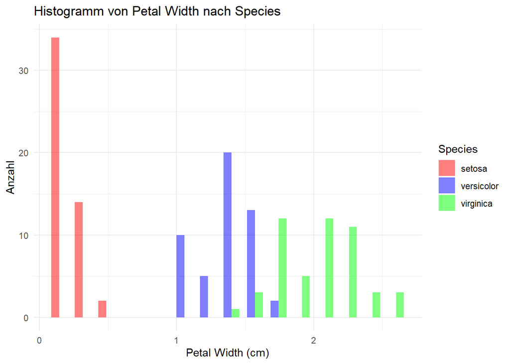

```r
# Histogramm für Petal.Width nach Species
ggplot(iris, aes(x = Petal.Width, fill = Species)) +
  geom_histogram(position = "dodge", bins = 15, alpha = 0.5) +
  scale_fill_manual(values = c("setosa" = "red", "versicolor" = "blue", "virginica" = "green")) +
  labs(title = "Histogramm von Petal Width nach Species",
       x = "Petal Width (cm)",
       y = "Anzahl") + theme_minimal()
```

Es sieht übersichtlicher als Density Curve aus statt Histogramm:

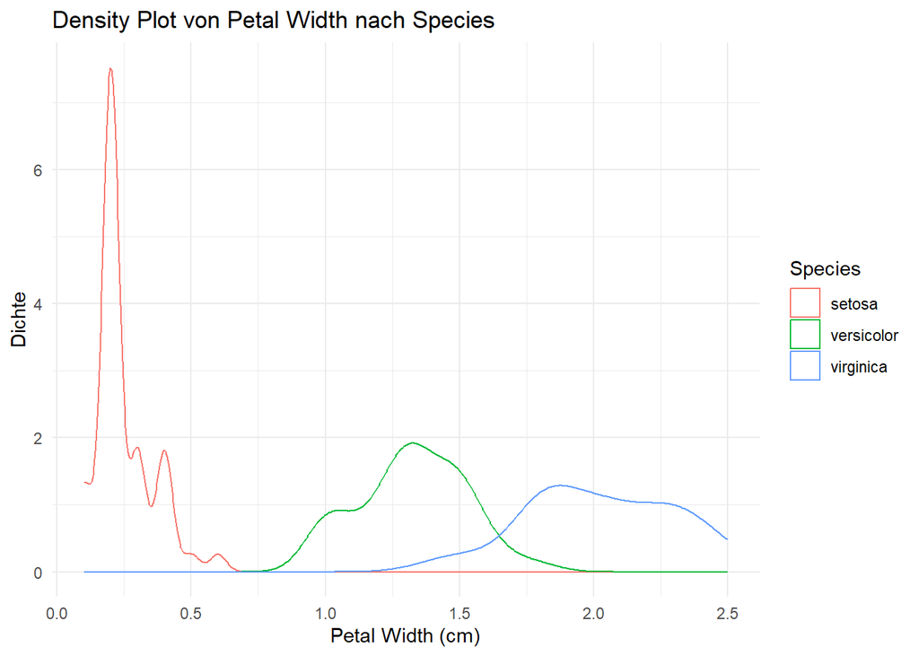

```r
# Density Plot für Petal.Width nach Species
ggplot(iris, aes(x = Petal.Width, color = Species)) +
  geom_density() +
  scale_fill_manual(values = c("setosa" = "red", "versicolor" = "blue", "virginica" = "green")) +
  labs(title = "Density Plot von Petal Width nach Species",
       x = "Petal Width (cm)",
       y = "Dichte") + theme_minimal()
```

- run the t-test of Petal.Width between setosa and virginica, and give the conclusion if the width is a statistically significant difference between 2 species

```r
# Daten für Setosa und Virginica selektieren
setosa <- iris$Petal.Width[iris$Species == "setosa"]
virginica <- iris$Petal.Width[iris$Species == "virginica"]

# T-Test durchführen
t_test_result <- t.test(setosa, virginica)

# T-Test Ergebnisse anzeigen
print(t_test_result)
```

```
##
##  Welch Two Sample t-test
##
## data:  setosa and virginica
## t = -42.786, df = 63.123, p-value < 2.2e-16
## alternative hypothesis: true difference in means is not equal to 0
## 95 percent confidence interval:
##  -1.863133 -1.696867
## sample estimates:
## mean of x mean of y
##     0.246     2.026
```

```r
# Schlussfolgerung
if(t_test_result$p.value < 0.05) {
  conclusion <- "Es gibt einen statistisch signifikanten Unterschied in der Petal Width zwischen Setosa und Virginica."
} else {
  conclusion <- "Es gibt keinen statistisch signifikanten Unterschied in der Petal Width zwischen Setosa und Virginica."
}
conclusion  # Zeigt die Schlussfolgerung an
```

```
## [1] "Es gibt einen statistisch signifikanten Unterschied in der Petal Width zwischen Setosa und Virginica."
```

Der p-value ist mit 2.2e-16 extrem klein, viel kleiner als 0.05, was bedeutet, dass es sehr sicher einen signifikanten Unterschied in der Petal Width zwischen Setosa und Virginica gibt.